# Week 2A SQL and R: Code Base

Author

Andre Thomson

## Approach

For this assignment, I asked six people to rate six animated movies. I used participant numbers instead of their names. The rating scale was:

- 1 = Did not like it
- 2 = It was okay
- 3 = I liked it
- 4 = I really liked it
- 5 = Loved it

Each person rated the movies they had seen. They could leave a question blank if they had not seen the movie. I stored the ratings in SQLite and used R to check the data and calculate the averages.

## Database design

I split the data into three tables. The users table has the participant numbers, the movies table has the movie titles, and the ratings table has the scores.

The ratings table uses the user ID and movie ID together as its primary key. This keeps a person from rating the same movie twice. I used foreign keys to connect the tables and a check rule to keep the ratings between 1 and 5.

The SQL file has the code used to create the tables, add the ratings, and check the results.

## Tools used

I used Google Forms to collect the ratings. I ran the SQL in SQLiteOnline and used Posit Cloud for the R work and this report. SQLite uses a local database file, so I did not need to place a password in the code.

I used Visual Studio Code and GitHub Copilot to help find errors. I checked the final SQL and R output before using it.

## Load the database

The SQLite database must be in the same folder as this Quarto file.

```r
library(DBI)
library(RSQLite)
library(dplyr)
library(tidyr)
library(ggplot2)
library(knitr)

db_file <- "movie_ratings.sqlite"

if (!file.exists(db_file)) {
  stop("movie_ratings.sqlite is missing. Run movie_ratings.sql first.")
}

con <- dbConnect(SQLite(), db_file)
```

## Load the SQL data into R

I joined the three tables so I could see the participant number, movie title, and rating in one dataframe. Each row is one rating.

```r
ratings <- dbGetQuery(
  con,
  "SELECT
      u.user_id,
      u.participant_id,
      m.movie_id,
      m.title AS movie_title,
      r.rating
   FROM ratings AS r
   INNER JOIN users AS u
      ON r.user_id = u.user_id
   INNER JOIN movies AS m
      ON r.movie_id = m.movie_id
   ORDER BY u.user_id, m.movie_id"
) |>
  as_tibble()

users <- dbReadTable(con, "users") |> as_tibble()
movies <- dbReadTable(con, "movies") |> as_tibble()

readr::write_csv(
  ratings,
  "movie_ratings_query.csv",
  na = ""
)
```

I checked the data before calculating the results.

```r
if (nrow(users) < 5) {
  stop("The assignment requires at least five participants.")
}

if (any(!ratings$rating %in% 1:5)) {
  stop("A rating is outside the 1 to 5 scale.")
}

if (anyDuplicated(ratings[c("user_id", "movie_id")]) > 0) {
  stop("A participant rated the same movie more than once.")
}

data_check <- tibble(
  check = c("Participants", "Movies", "Completed ratings"),
  result = c(nrow(users), nrow(movies), nrow(ratings))
)

kable(data_check, col.names = c("Check", "Result"))
```

| Check | Result |
| --- | --- |
| Participants | 6 |
| Movies | 6 |
| Completed ratings | 36 |

## Collected ratings

```r
ratings |>
  select(participant_id, movie_title, rating) |>
  kable(
    col.names = c("Participant", "Movie", "Rating"),
    align = c("l", "l", "r")
  )
```

| Participant | Movie | Rating |
| --- | --- | --- |
| Participant 1 | Puss in Boots: The Last Wish | 5 |
| Participant 1 | The Wild Robot | 5 |
| Participant 1 | Inside Out 2 | 5 |
| Participant 1 | Moana 2 | 5 |
| Participant 1 | Dog Man | 3 |
| Participant 1 | The Super Mario Bros. Movie | 4 |
| Participant 2 | Puss in Boots: The Last Wish | 5 |
| Participant 2 | The Wild Robot | 5 |
| Participant 2 | Inside Out 2 | 3 |
| Participant 2 | Moana 2 | 5 |
| Participant 2 | Dog Man | 2 |
| Participant 2 | The Super Mario Bros. Movie | 4 |
| Participant 3 | Puss in Boots: The Last Wish | 3 |
| Participant 3 | The Wild Robot | 2 |
| Participant 3 | Inside Out 2 | 1 |
| Participant 3 | Moana 2 | 2 |
| Participant 3 | Dog Man | 5 |
| Participant 3 | The Super Mario Bros. Movie | 5 |
| Participant 4 | Puss in Boots: The Last Wish | 3 |
| Participant 4 | The Wild Robot | 5 |
| Participant 4 | Inside Out 2 | 2 |
| Participant 4 | Moana 2 | 3 |
| Participant 4 | Dog Man | 4 |
| Participant 4 | The Super Mario Bros. Movie | 5 |
| Participant 5 | Puss in Boots: The Last Wish | 5 |
| Participant 5 | The Wild Robot | 4 |
| Participant 5 | Inside Out 2 | 1 |
| Participant 5 | Moana 2 | 1 |
| Participant 5 | Dog Man | 1 |
| Participant 5 | The Super Mario Bros. Movie | 5 |
| Participant 6 | Puss in Boots: The Last Wish | 5 |
| Participant 6 | The Wild Robot | 5 |
| Participant 6 | Inside Out 2 | 3 |
| Participant 6 | Moana 2 | 3 |
| Participant 6 | Dog Man | 2 |
| Participant 6 | The Super Mario Bros. Movie | 5 |

## Missing ratings

I did not use zero when someone had not seen a movie. Zero is not part of the scale and would lower the average. A blank answer is handled by leaving out that rating row.

I checked every person against every movie. If a rating was missing, R showed it as a missing value.

```r
all_combinations <- crossing(
  users |> select(user_id, participant_id),
  movies |> select(movie_id, movie_title = title)
)

complete_ratings <- all_combinations |>
  left_join(
    ratings |> select(user_id, movie_id, rating),
    by = c("user_id", "movie_id")
  )

missing_ratings <- complete_ratings |>
  filter(is.na(rating))

if (nrow(missing_ratings) == 0) {
  cat("There are no missing ratings in this dataset.")
} else {
  missing_ratings |>
    select(participant_id, movie_title) |>
    kable(col.names = c("Participant", "Movie left blank"))
}
```

```
There are no missing ratings in this dataset.
```

No one left a movie blank in this set of responses. The code still checks for missing ratings and keeps them missing instead of changing them to zero.

## Ratings by participant

```r
participant_summary <- complete_ratings |>
  group_by(participant_id) |>
  summarise(
    movies_rated = sum(!is.na(rating)),
    movies_left_blank = sum(is.na(rating)),
    .groups = "drop"
  )

kable(
  participant_summary,
  col.names = c("Participant", "Movies rated", "Movies left blank")
)
```

| Participant | Movies rated | Movies left blank |
| --- | --- | --- |
| Participant 1 | 6 | 0 |
| Participant 2 | 6 | 0 |
| Participant 3 | 6 | 0 |
| Participant 4 | 6 | 0 |
| Participant 5 | 6 | 0 |
| Participant 6 | 6 | 0 |

## Average rating by movie

```r
movie_summary <- complete_ratings |>
  group_by(movie_title) |>
  summarise(
    number_of_ratings = sum(!is.na(rating)),
    average_rating = mean(rating, na.rm = TRUE),
    .groups = "drop"
  ) |>
  mutate(
    average_rating = if_else(
      is.nan(average_rating),
      NA_real_,
      average_rating
    )
  ) |>
  arrange(desc(average_rating), movie_title)

movie_summary |>
  mutate(average_rating = round(average_rating, 2)) |>
  kable(
    col.names = c("Movie", "Number of ratings", "Average rating"),
    align = c("l", "r", "r")
  )
```

| Movie | Number of ratings | Average rating |
| --- | --- | --- |
| The Super Mario Bros. Movie | 6 | 4.67 |
| Puss in Boots: The Last Wish | 6 | 4.33 |
| The Wild Robot | 6 | 4.33 |
| Moana 2 | 6 | 3.17 |
| Dog Man | 6 | 2.83 |
| Inside Out 2 | 6 | 2.50 |

I included the number of ratings used for each average.

## Chart

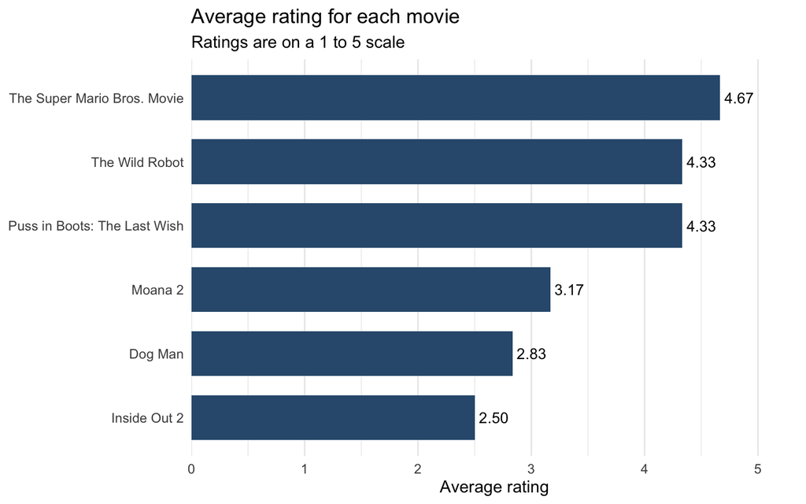

```r
ggplot(
  movie_summary,
  aes(x = reorder(movie_title, average_rating), y = average_rating)
) +
  geom_col(fill = "#315A7D", width = 0.7, na.rm = TRUE) +
  geom_text(
    aes(label = sprintf("%.2f", average_rating)),
    hjust = -0.15,
    size = 3.8,
    na.rm = TRUE
  ) +
  coord_flip() +
  scale_y_continuous(
    limits = c(0, 5.35),
    breaks = 0:5,
    expand = expansion(mult = c(0, 0))
  ) +
  labs(
    title = "Average rating for each movie",
    subtitle = "Ratings are on a 1 to 5 scale",
    x = NULL,
    y = "Average rating"
  ) +
  theme_minimal(base_size = 12) +
  theme(panel.grid.major.y = element_blank())
```

## Findings

The Super Mario Bros. Movie came out on top for this group, while Inside Out 2 had the lowest average. Everyone answered all six movie questions, so the averages are based on the same group of people. I did not have to remove or fill in any blank ratings for this set of responses.

Only six people completed the form, so these results describe this group only.

## Conclusion

I created the tables in SQLite, joined them by their IDs, and loaded the results into R. I checked for missing ratings and calculated the average for each movie.

## Sources and references

- [SQLite CREATE TABLE documentation](https://www.sqlite.org/lang_createtable.html) for primary keys, foreign keys, and rating checks.
- [DBI introduction](https://dbi.r-dbi.org/articles/DBI.html) for connecting R to the SQLite database.
- [SQLBolt lessons](https://sqlbolt.com/) for a tutorial review of joins and queries.
- Wickham, Çetinkaya-Rundel, and Grolemund, [R for Data Science (2e), Chapter 21: Databases](https://r4ds.hadley.nz/databases.html), for the R/database workflow.
- [Quarto’s RStudio tutorial](https://quarto.org/docs/get-started/hello/rstudio.html) for the report format and rendering steps.
- Mine Çetinkaya-Rundel, [Get started with Quarto](https://www.youtube.com/watch?v=_f3latmOhew), a video overview of Quarto.